# Analysis of Air Travel in September 2018

Author

Josh Sweren

Published

December 1, 2025

[Main Data Source](https://www.transtats.bts.gov/Fields.asp?gnoyr_VQ=FGJ)[^1]

## Introduction

September is commonly considered a month of infrequent passenger travel in the U.S. considering its relatively hospitable whether and proximity to high-travel periods. It lands squarely between the frequently travelled summer where children are on a break from school and even cold-weather destinations become desirable, and the autumn/winter holiday season where people are eager to visit loved ones or enjoy a warmer climate. According to the Bureau of Transportation Statistics (BTS), September trails only February in total passenger enplanements over the last 25 years.[^2]

As a result, it is reasonable to surmise that this may be a period of decreased scrutiny over air travel performance, and that airlines may consider the lower traffic to be a respite from the high-stakes rushes preceding and following it. This project will analyze Federal Aviation Administration (FAA) data published by the BTS from September 2018 to evaluate airport performance during a period that may otherwise be easily overlooked. It will leverage a selection of prescribed queries that have been executed to gather a limited set of metadata regarding all flights from this time frame.

## Data Analysis

### Flight Volume

```r
library(ggplot2)
library(tidyverse)
library(airportr)
library(stringr)
library(tidygeocoder)
library(leaflet)
library(htmltools)
```

Before evaluating airport and airline performance in September 2018, it can be helpful to visualize when the highest volumes of flights are scheduled. This will allow us to make inferences on how airlines operate and cater to certain customers. One way to do this is to look at flight volumes by day of the week. The following chart shows the number of flights per day, grouped by day of the week. Since our month in question contained five Saturdays and Sundays, but four of every other day, it was important to look at averages rather than raw numbers which would be skewed.

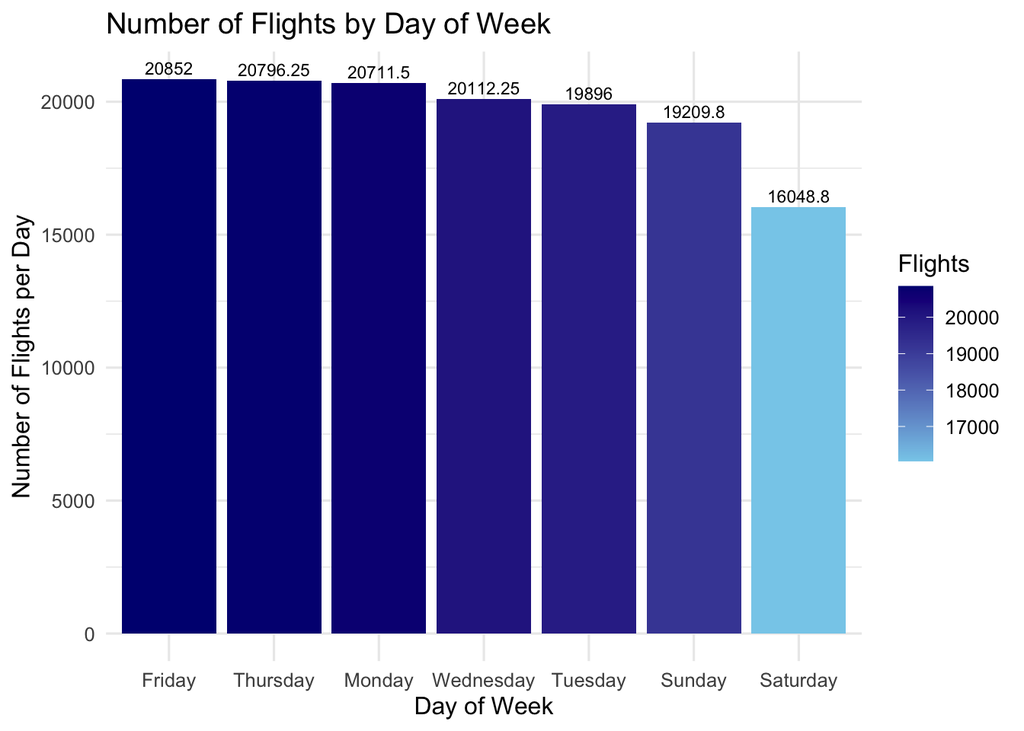

```r
days <- read.csv("../Output tables/problem3_output.csv")
day_counts <- c(
  "Sunday" = 5,
  "Monday" = 4,
  "Tuesday" = 4,
  "Wednesday" = 4,
  "Thursday" = 4,
  "Friday" = 4,
  "Saturday" = 5
)
days <- days %>%
  mutate(
    flights_per_day = num_flights / day_counts[Day]
  )
days %>%
  ggplot(aes(x = reorder(Day, -flights_per_day),
             y = flights_per_day,
             fill = flights_per_day)) +
  geom_col() +
  scale_fill_gradient(low = "skyblue", high = "navy") +
  labs(
    title = "Number of Flights by Day of Week",
    x = "Day of Week",
    y = "Number of Flights per Day",
    fill = "Flights"
  ) +
  geom_text(aes(label = flights_per_day),
            vjust = -0.4,
            size = 3) +
  theme_minimal(base_size = 12)
```

The main takeaway from this bar chart is that weekends clearly have a lesser volume than weekdays, indicating a tendency to follow the average work week. Meanwhile, the fact that Friday, Thursday, and Monday are the three highest volumes and are relatively close together shows us that airlines apply some consideration towards travelling for the weekend, both before and after it. Both of these observations imply that air travel undeniably conforms to the lifestyle of its consumers, which puts great importance on punctuality of flights.

In the next plot, we will confirm some of these observations by looking at daily volumes and three-day moving averages.

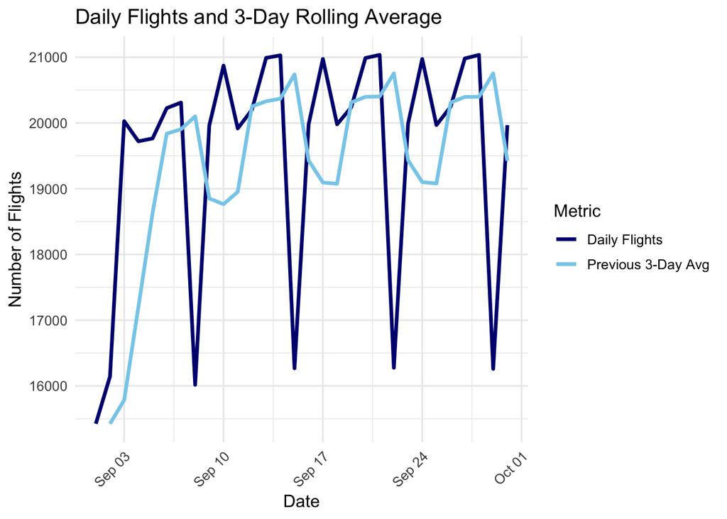

```r
avgs <- read.csv("../Output tables/problem7_output.csv")
avgs$prev_3_avg[avgs$prev_3_avg == "NULL"] <- NA
avgs$prev_3_avg <- as.numeric(avgs$prev_3_avg)
avgs$FlightDate <- as.Date(avgs$FlightDate)
avgs_long <- avgs %>%
  pivot_longer(cols = c(num_flights, prev_3_avg),
               names_to = "metric",
               values_to = "value")

ggplot(avgs_long, aes(x = FlightDate, y = value, color = metric)) +
  geom_line(linewidth = 1.2) +
  scale_color_manual(
    values = c(
      "num_flights" = "navy",
      "prev_3_avg"  = "skyblue"
    ),
    labels = c(
      "num_flights" = "Daily Flights",
      "prev_3_avg"  = "Previous 3-Day Avg"
    )
  ) +
  labs(
    title = "Daily Flights and 3-Day Rolling Average",
    x = "Date",
    y = "Number of Flights",
    color = "Metric"
  ) +
  theme_minimal(base_size = 12) +
  theme(
    axis.text.x = element_text(angle = 45, hjust = 1)
  )
```

This plot validates that air travel, even within a single month, is highly cyclical based on day of week. We see peaks at the beginnings and ends of work weeks and declines on weekends. Another observation is that there are lesser values in the first week of the month, around Labor Day. This furthers the notion that air travel peaks when Americans tend to be working.

### Airport Performance

Now that we understand some of the motives behind scheduling flights, we can analyze the performance of air travel as it relates to each airport. A good way to visualize this is geospatially, showing airports in a way that may be of value to customers. This can be achieved by leveraging OpenStreetMap (OSM) data via the `tidygeocoder` R package for geolocating the airports and using the `leaflet` package for visualization. Airports that were not automatically located with OSM were manually located by researching coordinates.

The first plot shows airports who account for the largest average delay time for each airline. Flights that are on time or early are considered to have a delay time of 0, so combinations of airlines and airports with few delays are heavily weighted towards 0. This map is hoverable to find the exact city and corresponding airline(s) and the circles are sized based on how many airlines have that airport as their largest average delay location.

#### Airports with Largest Average Delay for each Airline

*Points are hoverable and sized by number of airlines per location.*

```r
delays <- read.csv("../Output tables/problem5_output.csv")
delays <- delays %>%
  mutate(clean = sub(":.*", "", Airport)) %>%
  geocode(address = clean, method = "osm")
df_summary <- delays %>%
  group_by(clean, lat, long) %>%
  summarise(
    count = n(),
    airlines = paste(unique(Airline), collapse = ", "),
    .groups = "drop"
  )
df_summary <- df_summary %>%
  mutate(
    label_html = paste0("<b>", clean, "<br>Airlines:</b> ", airlines)
  )
df_summary <- df_summary %>%
  mutate(
    lat = ifelse(clean == "Bristol/Johnson City/Kingsport, TN", 36.48180246957566, lat),
    long = ifelse(clean == "Bristol/Johnson City/Kingsport, TN", -82.40745941203505, long)
  )
leaflet(df_summary) %>%
  addTiles() %>%
  addCircleMarkers(
    ~long, ~lat,
    radius = ~5 + count**2,
    color = "blue",
    fillOpacity = 0.6,
    label = lapply(df_summary$label_html, HTML),
    labelOptions = labelOptions(
      direction = "auto",
      opacity = 0.9,
      textsize = "13px"
    ))
```

[interactive chart not shown]

What this map tells us is first that the Dallas/Fort Worth airport is the only one in the country to account for multiple airlines’ greatest average delay. From a geographic standpoint, most of these airports are either in the south, are small airports along the east coast, or belong in Alaska or Hawaii, which are interestingly overrepresented here. For potential customers, this could serve as interesting data to inform decisions about where to travel from.

Moving on from flight delays, flight cancellations are another unfortunate consideration for passengers. Understanding why flights are cancelled can have predictive value, while also allowing us to analyze the specific issues afflicting air travel in September 2018. Due to the diversity in capabilities and geography of airports around the country, we will take a look at the most common reason for cancellation for each airport. This bar chart simply counts the airports with each most common reason for cancellation.

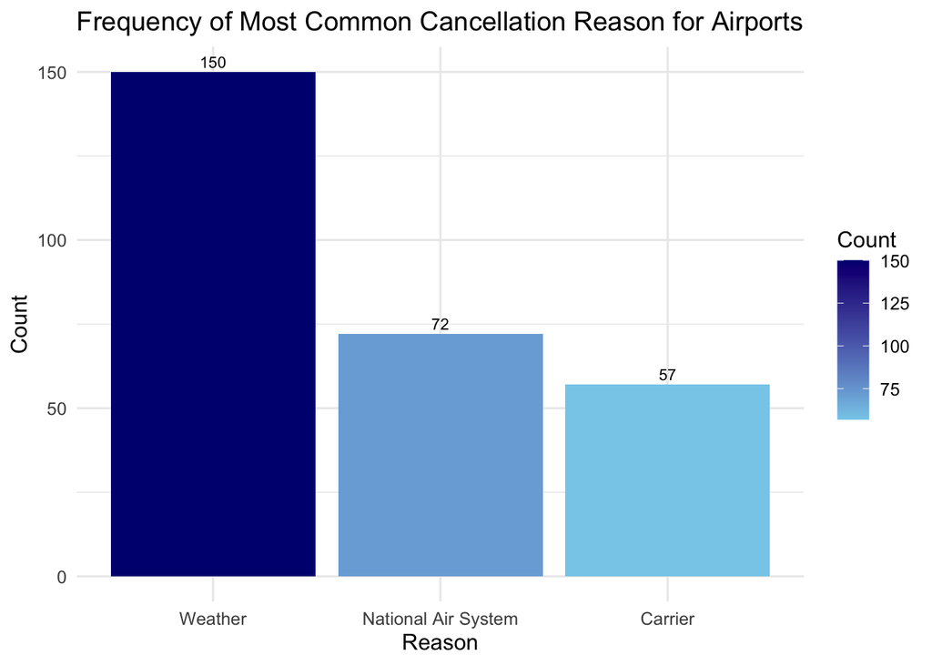

```r
cancellations <- read.csv("../Output tables/problem6b_output.csv")
df_counts <- cancellations %>%
  count(freq_reason) %>%
  arrange(desc(n))
ggplot(df_counts, aes(x = reorder(freq_reason, -n), y = n, fill = n)) +
  geom_col() +
  scale_fill_gradient(low = "skyblue", high = "navy") +
  geom_text(aes(label = n), vjust = -0.4, size = 3) +
  labs(
    title = "Frequency of Most Common Cancellation Reason for Airports",
    x = "Reason",
    y = "Count",
    fill = "Count"
  ) +
  theme_minimal(base_size = 12)
```

This bar chart tells us that more than half of airports with travel in September 2018 had weather as the most common reason for cancellation, an observation that will not be surprising to most travellers. However, the significant presence of airports most commonly affected by the National Air System or the Carrier leaves us with more work to do.

This map will plot the above data geospatially to better understand where these issues most commonly arise. Once again, we will leverage OSM data and `leaflet` to produce an informative map.

#### Most Common Cancellation Reason per Airport

*Zoom in to see more specific results. Map is zoomed out to account for Guam.*

```r
cancellations <- cancellations %>%
  mutate(clean = sub(":.*", "", Name)) %>%
  geocode(address = clean, method = "osm")

cancellations <- cancellations %>%
  mutate(
    lat = ifelse(clean == "Ontario, CA", 34.059401049954516, lat),
    long = ifelse(clean == "Ontario, CA", -117.58881697620873, long)
  )
cancellations <- cancellations %>%
  mutate(
    lat = ifelse(clean == "Cedar Rapids/Iowa City, IA", 41.88601104362796, lat),
    long = ifelse(clean == "Cedar Rapids/Iowa City, IA", -91.70791699273752, long)
  )
cancellations <- cancellations %>%
  mutate(
    lat = ifelse(clean == "Mission/McAllen/Edinburg, TX", 26.18285758077025, lat),
    long = ifelse(clean == "Mission/McAllen/Edinburg, TX", -98.22264583474204, long)
  )
cancellations <- cancellations %>%
  mutate(
    lat = ifelse(clean == "New Bern/Morehead/Beaufort, NC", 35.07366390169133, lat),
    long = ifelse(clean == "New Bern/Morehead/Beaufort, NC", -77.04096532559154, long)
  )
cancellations <- cancellations %>%
  mutate(
    lat = ifelse(clean == "Newburgh/Poughkeepsie, NY", 41.498579954715005, lat),
    long = ifelse(clean == "Newburgh/Poughkeepsie, NY", -74.10037990625136, long)
  )
cancellations <- cancellations %>%
  mutate(
    lat = ifelse(clean == "Saginaw/Bay City/Midland, MI", 43.53878406192279, lat),
    long = ifelse(clean == "Saginaw/Bay City/Midland, MI", -84.0815316761024, long)
  )
pal <- colorFactor(
  palette = "Set1",
  domain = cancellations$freq_reason
)
leaflet(cancellations) %>%
  addTiles() %>%
  addCircleMarkers(
    ~long, ~lat,
    radius = 2,
    color = ~pal(freq_reason),
    fillOpacity = 0.7,
    label = ~paste0("<b>", clean, "</b><br>Reason: ", freq_reason) %>% lapply(htmltools::HTML),
    labelOptions = labelOptions(
      direction = "auto",
      opacity = 0.9,
      textsize = "13px"
    )
  ) %>%
  addLegend(
    "bottomright",
    pal = pal,
    values = ~freq_reason,
    title = "Most Frequent Cancellation Reason",
    opacity = 1
  )
```

[interactive chart not shown]

This map offers clear geospatial patterns regarding cancellation reasons across the country. Firstly, it is clear that weather-related cancellations affect all areas of the country, but have greatest prevalence in the southeast and great plains areas, both of which are known for erratic weather.

Carrier-related cancellations appear to be most common for smaller airports, including alarming prevalence in Alaska, Hawaii, and New England. One hypothesis for this phenomenon is that less reputable carriers with smaller aircrafts tend to fly out of these locations. Meanwhile, National Air System caused cancellations mainly in the central time zone area, with an unmistakeable strip ranging from Texas/Louisiana to Wisconsin/Michigan.

## Conclusions

These visualizations help us understand some of the issues that afflicted air travel in September 2018, the extent of their impact, and where they had the greatest effect. It is evident that airlines tailor their schedules to accomodate the average work schedule of their customers, but consistent delays and harsh weather can prove costly for many. Across the country, airports deal with unique assortments of challenges, many of which are informed by geographic location.

Ultimately, further statistical analyses require a more exhasutive set of queries to specifically hone in on these topics, but even our limited metadata tables help visualize the air travel landscape from a chosen month. Even in a period of lower traffic, flight punctuality remains crucial for many passengers to seamlessly integrate travel into their lives. Additionally, understanding this information can assist airports, airlines, and customers going into the frantic fall/winter holiday season.

## Footnotes

[^1]: “On-Time : Reporting Carrier On-Time Performance (1987-present),” Bureau of Transportation Statistics, https://www.transtats.bts.gov/Fields.asp?gnoyr_VQ=FGJ (accessed Dec. 1, 2025).
[^2]: “U.S. Air Carrier Traffic Statistics,” Bureau of Transportation Statistics, https://www.transtats.bts.gov/traffic/ (accessed Dec. 1, 2025).